# Analysis of the Adverse Health and Economic Impacts of US Storms

Kieso Jan

7/23/2021

## 1: Synopsis

The goal of this analysis is to explore the NOAA Storm Database and explore the effects of severe weather events on both population and economy. The events in the database start in the year 1950 and end in November 2011. this analysis is aiming to answer:

1. Across the United States, which types of events are most harmful with respect to population health?
2. Across the United States, which types of events have the greatest economic consequences?

Information on the Data: [Documentation](https://d396qusza40orc.cloudfront.net/repdata%2Fpeer2_doc%2Fpd01016005curr.pdf)

```r
library(data.table)
library(ggplot2)
library(dplyr,warn.conflicts = FALSE)
```

```r
DatafileUrl <- "https://d396qusza40orc.cloudfront.net/repdata%2Fdata%2FStormData.csv.bz2"
download.file(DatafileUrl, destfile = paste0("data", '/repdata_data_StormData.csv.bz2'))
```

```r
stormDF <- read.csv("data/repdata_data_StormData.csv.bz2")
```

### 2.2: Examining Column Names

```r
colnames(stormDF)
```

```
##  [1] "STATE__"    "BGN_DATE"   "BGN_TIME"   "TIME_ZONE"  "COUNTY"
##  [6] "COUNTYNAME" "STATE"      "EVTYPE"     "BGN_RANGE"  "BGN_AZI"
## [11] "BGN_LOCATI" "END_DATE"   "END_TIME"   "COUNTY_END" "COUNTYENDN"
## [16] "END_RANGE"  "END_AZI"    "END_LOCATI" "LENGTH"     "WIDTH"
## [21] "F"          "MAG"        "FATALITIES" "INJURIES"   "PROPDMG"
## [26] "PROPDMGEXP" "CROPDMG"    "CROPDMGEXP" "WFO"        "STATEOFFIC"
## [31] "ZONENAMES"  "LATITUDE"   "LONGITUDE"  "LATITUDE_E" "LONGITUDE_"
## [36] "REMARKS"    "REFNUM"
```

since it’s not all of columns will be used, Let’s only keep columns relevant to following analysis:

1. EVTYPE 2.FATALITIES 3.INJURIES 4.PROPDMG 5.PROPDMGEXP 6.CROPDMG 7.CROPDMGEXP

### 2.3: Data Subsetting

Basically, we remove the columns we don’t need for clarity in this analysis, and keep rows is not (1) unknown (2) value > 0

```r
# Finding columns to keep
stormDF<- select(stormDF, c("EVTYPE"
                         , "FATALITIES"
                         , "INJURIES"
                         , "PROPDMG"
                         , "PROPDMGEXP"
                         , "CROPDMG"
                         , "CROPDMGEXP")) %>%
## Only use data where fatalities or injuries occurred.
             filter(EVTYPE != "?" &
             (INJURIES > 0 | FATALITIES > 0 | PROPDMG > 0 | CROPDMG > 0))

str(stormDF)
```

[output not shown]

### 2.4: Converting Exponent Columns into Actual Exponents instead of (-,+, H, K, etc)

Based on the Explanation of document. Alphabetical characters used to signify magnitude include “K” for thousands, “M” for millions, and “B” for billions.

```r
stormDF$PROPDMGEXP <-  toupper(stormDF$PROPDMGEXP)
stormDF$CROPDMGEXP <-  toupper(stormDF$CROPDMGEXP)

table(stormDF$PROPDMGEXP)
```

```
##
##             -      +      0      2      3      4      5      6      7      B
##  11585      1      5    210      1      1      4     18      3      3     40
##      H      K      M
##      7 231427  11327
```

```r
table(stormDF$CROPDMGEXP)
```

```
##
##             ?      0      B      K      M
## 152663      6     17      7  99953   1986
```

```r
# Map property damage alphanumeric exponents to numeric values.

stormDF <- stormDF %>% mutate(PROPDMGEXP
                          = case_when(
                           PROPDMGEXP == "\"\"" ~ 10^0,
                           PROPDMGEXP ==  "-" ~ 10^0,
                           PROPDMGEXP ==  "+" ~ 10^0,
                           PROPDMGEXP ==  "0" ~ 10^0,
                           PROPDMGEXP ==  "1" ~ 10^1,
                           PROPDMGEXP ==  "2" ~ 10^2,
                           PROPDMGEXP ==  "3" ~ 10^3,
                           PROPDMGEXP ==  "4" ~ 10^4,
                           PROPDMGEXP ==  "5" ~ 10^5,
                           PROPDMGEXP ==  "6" ~ 10^6,
                           PROPDMGEXP ==  "7" ~ 10^7,
                           PROPDMGEXP ==  "8" ~ 10^8,
                           PROPDMGEXP ==  "9" ~ 10^9,
                           PROPDMGEXP ==  "H" ~ 10^2,
                           PROPDMGEXP ==  "K" ~ 10^3,
                           PROPDMGEXP ==  "M" ~ 10^6,
                           PROPDMGEXP ==  "B" ~ 10^9
                           ))

stormDF <- stormDF %>% mutate(PROPDMGEXP = if_else(is.na(PROPDMGEXP),10^0,PROPDMGEXP))


# Map crop damage alphanumeric exponents to numeric values

stormDF <- stormDF %>% mutate(CROPDMGEXP
                          = case_when(
                           CROPDMGEXP ==  "?" ~ 10^0,
                           CROPDMGEXP ==  "0" ~ 10^0,
                           CROPDMGEXP ==  "K" ~ 10^3,
                           CROPDMGEXP ==  "M" ~ 10^6,
                           CROPDMGEXP ==  "B" ~ 10^9
                           ))

stormDF <- stormDF %>% mutate(CROPDMGEXP = if_else(is.na(CROPDMGEXP),10^0,CROPDMGEXP))

table(stormDF$PROPDMGEXP)
table(stormDF$CROPDMGEXP)
```

[output not shown]

### 2.5: Making Economic Cost Columns

```r
stormDF <- stormDF %>% mutate(propCost = PROPDMG * PROPDMGEXP,
                              cropCost = CROPDMG * CROPDMGEXP)
```

### 2.6: Making a summary result for total cost of Property and Crop

```r
totalCostDF <- stormDF %>% group_by(EVTYPE) %>%
  summarize(propCost = sum(propCost), cropCost = sum(cropCost),
            Total_Cost  = sum(propCost) + sum(cropCost)) %>%
            arrange(desc(Total_Cost))

totalCostDF <- head(totalCostDF, 10)

head(totalCostDF, 5)
```

```
## # A tibble: 5 x 4
##   EVTYPE                 propCost   cropCost    Total_Cost
##   <chr>                     <dbl>      <dbl>         <dbl>
## 1 FLOOD             144657709807  5661968450 150319678257
## 2 HURRICANE/TYPHOON  69305840000  2607872800  71913712800
## 3 TORNADO            56947380676.  414953270  57362333946.
## 4 STORM SURGE        43323536000        5000  43323541000
## 5 HAIL               15735267513. 3025954473  18761221986.
```

### ### 2.7:Making a summary result for Total Fatalities and Injuries

```r
totalInjuriesDT <- stormDF %>% group_by(EVTYPE) %>%
  summarize(FATALITIES = sum(FATALITIES),
            INJURIES = sum(INJURIES),
            totals  = sum(FATALITIES) + sum(INJURIES)) %>%
  arrange(desc(FATALITIES))

totalInjuriesDT <- head(totalInjuriesDT, 10)

head(totalInjuriesDT, 5)
```

```
## # A tibble: 5 x 4
##   EVTYPE         FATALITIES INJURIES totals
##   <chr>               <dbl>    <dbl>  <dbl>
## 1 TORNADO              5633    91346  96979
## 2 EXCESSIVE HEAT       1903     6525   8428
## 3 FLASH FLOOD           978     1777   2755
## 4 HEAT                  937     2100   3037
## 5 LIGHTNING             816     5230   6046
```

## 3: Findings & Conclustions

### 3.1: Top 10 Events that are Most Harmful to Population Health

Melting data format so that it is easier to put in bar graph format

```r
terrible_things <- melt(totalInjuriesDT, id.vars="EVTYPE", variable.name = "terrible_thing")
head(terrible_things, 5)
```

```
##           EVTYPE terrible_thing value
## 1        TORNADO     FATALITIES  5633
## 2 EXCESSIVE HEAT     FATALITIES  1903
## 3    FLASH FLOOD     FATALITIES   978
## 4           HEAT     FATALITIES   937
## 5      LIGHTNING     FATALITIES   816
```

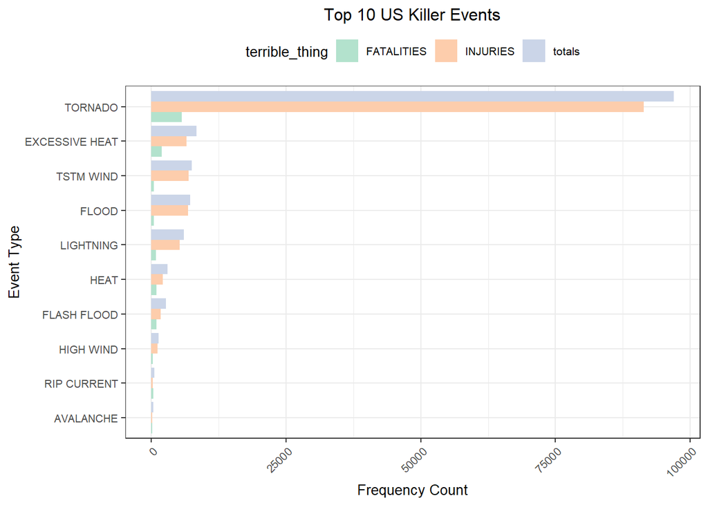

```r
ggplot(terrible_things, aes(x=reorder(EVTYPE, value), y=value)) +
  theme_bw() +
  # Plot data as bar chart
  geom_bar(stat="identity", aes(fill=terrible_thing), position="dodge") +
  # Format y-axis scale and set y-axis label
  ylab("Frequency Count") +  xlab("Event Type") +
  # Rotate x-axis tick labels
  theme(axis.text.x = element_text(angle=45, hjust=1)) +
  ggtitle("Top 10 US Killer Events") +
  # Set chart title and center it
  theme(plot.title = element_text(hjust = 0.5)) +
  # apply chart theme
  scale_fill_brewer(palette="Pastel2")  +
  # setup legend
  theme(legend.position = "top", text = element_text(size = 10)) +
  coord_flip()
```

### 3.2: Events that have the Greatest Economic Consequences

Melting data format so that it is easier to put in bar graph format

```r
econ_consequences <- melt(totalCostDF, id.vars="EVTYPE", variable.name = "Damage_Type")
head(econ_consequences, 5)
```

```
##              EVTYPE Damage_Type        value
## 1             FLOOD    propCost 144657709807
## 2 HURRICANE/TYPHOON    propCost  69305840000
## 3           TORNADO    propCost  56947380677
## 4       STORM SURGE    propCost  43323536000
## 5              HAIL    propCost  15735267513
```

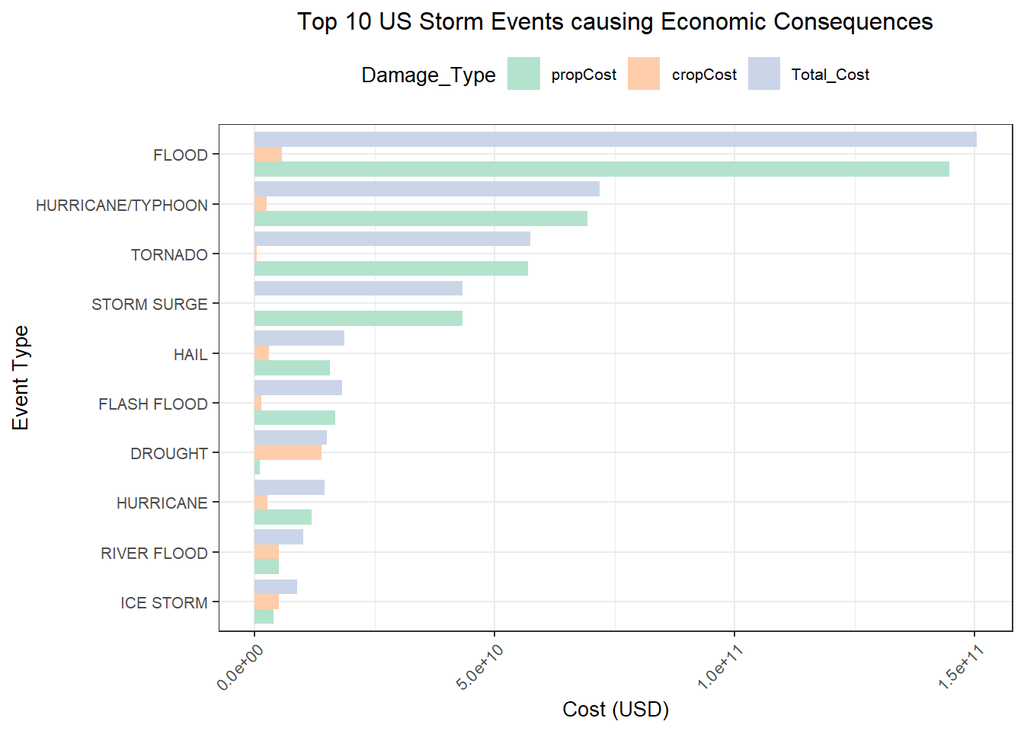

```r
  ggplot(econ_consequences, aes(x=reorder(EVTYPE, value), y=value)) +
  theme_bw() +
  # Plot data as bar chart
  geom_bar(stat="identity", aes(fill=Damage_Type), position="dodge") +
  # Format y-axis scale and set y-axis label
  ylab("Cost (USD)") +  xlab("Event Type") +
  # Rotate x-axis tick labels
  theme(axis.text.x = element_text(angle=45, hjust=1)) +
  # Set chart title and center it
  ggtitle("Top 10 US Storm Events causing Economic Consequences") +
  theme(plot.title = element_text(hjust = 0.5)) +
  scale_fill_brewer(palette="Pastel2")  +
  theme(legend.position = "top", text = element_text(size = 10)) +
  coord_flip()
```